# Data Manipulation - dplyr

Jiuru Lyu

2022-10-25

# Import Data Set and Packages

```r
gss <- read.csv("newgss.csv")
```

```r
library(tidyverse)
library(babynames)
```

# `dplyr` Introduction

`dplyr` provides simple *verbs*, functions that correspond to the most common data manipulation tasks, to help you translate your thoughts into code.

`dplyr` aims to provide a function for each basic verb of data manipulation:

- filter() to select cases based on their values.
- arrange() to give cases/observations a specific order
- select() to select variables based on their names.
- mutate() to add new variables that are functions of existing variables.
- group_by() to split the data frame into pieces based on some variables.
- summarize() to condense multiple values to a single value.

*split-apply-combine*: A common analytical pattern is to split data frame into pieces, apply some function to each pieces, and combine the results back together again to a new data frame.

All verbs work similarly: 1. The first argument is a data frame; 2. The subsequent arguments describe what to do with the data frame, using the variable names (without quotes); 3. The result is a new data frame

## The Pipe Operator: `%>%`

Pipes take the output from one function and feed it to the first argument of the next function. Instead of nesting functions (reading from the inside to the outside), the idea of of piping is to read the functions from left to right.

## The `filter()` Verb

We use `filter()` to select cases/observations/rows based on their values.

```r
# Select all the respondents in 2000
gss %>%
  filter(year == 2000) %>%
  head()
```

```
##     X.1     X          region         income        happy age       finrela
## 1 36504 36504 W. SOU. CENTRAL           <NA> PRETTY HAPPY  26 ABOVE AVERAGE
## 2 36505 36505 W. SOU. CENTRAL  $8000 TO 9999 PRETTY HAPPY  48 BELOW AVERAGE
## 3 36506 36506 W. SOU. CENTRAL $15000 - 19999 PRETTY HAPPY  67 BELOW AVERAGE
## 4 36507 36507 W. SOU. CENTRAL $25000 OR MORE   VERY HAPPY  39 ABOVE AVERAGE
## 5 36508 36508 W. SOU. CENTRAL $25000 OR MORE PRETTY HAPPY  25 ABOVE AVERAGE
## 6 36509 36509 W. SOU. CENTRAL           <NA> PRETTY HAPPY  25          <NA>
##         marital         degree    health          wrkstat            partyid
## 1 NEVER MARRIED       BACHELOR EXCELLENT WORKING FULLTIME       IND NEAR REP
## 2      DIVORCED    HIGH SCHOOL      FAIR WORKING FULLTIME NOT STR REPUBLICAN
## 3       WIDOWED    HIGH SCHOOL      GOOD    KEEPING HOUSE        INDEPENDENT
## 4 NEVER MARRIED    HIGH SCHOOL      <NA> WORKING FULLTIME       IND NEAR REP
## 5      DIVORCED JUNIOR COLLEGE      <NA> WORKING FULLTIME   NOT STR DEMOCRAT
## 6       MARRIED    HIGH SCHOOL      GOOD WORKING FULLTIME    STRONG DEMOCRAT
##               polviews    sex year income1
## 1 SLGHTLY CONSERVATIVE   MALE 2000      NA
## 2         CONSERVATIVE FEMALE 2000    9000
## 3         CONSERVATIVE FEMALE 2000   17500
## 4 SLGHTLY CONSERVATIVE FEMALE 2000   25000
## 5     SLIGHTLY LIBERAL FEMALE 2000   25000
## 6     SLIGHTLY LIBERAL FEMALE 2000      NA
```

```r
# Select all the respondents in 2000 and 2001
gss %>%
  filter(year == 2000 | year == 2001) %>%
  head()
```

```
##     X.1     X          region         income        happy age       finrela
## 1 36504 36504 W. SOU. CENTRAL           <NA> PRETTY HAPPY  26 ABOVE AVERAGE
## 2 36505 36505 W. SOU. CENTRAL  $8000 TO 9999 PRETTY HAPPY  48 BELOW AVERAGE
## 3 36506 36506 W. SOU. CENTRAL $15000 - 19999 PRETTY HAPPY  67 BELOW AVERAGE
## 4 36507 36507 W. SOU. CENTRAL $25000 OR MORE   VERY HAPPY  39 ABOVE AVERAGE
## 5 36508 36508 W. SOU. CENTRAL $25000 OR MORE PRETTY HAPPY  25 ABOVE AVERAGE
## 6 36509 36509 W. SOU. CENTRAL           <NA> PRETTY HAPPY  25          <NA>
##         marital         degree    health          wrkstat            partyid
## 1 NEVER MARRIED       BACHELOR EXCELLENT WORKING FULLTIME       IND NEAR REP
## 2      DIVORCED    HIGH SCHOOL      FAIR WORKING FULLTIME NOT STR REPUBLICAN
## 3       WIDOWED    HIGH SCHOOL      GOOD    KEEPING HOUSE        INDEPENDENT
## 4 NEVER MARRIED    HIGH SCHOOL      <NA> WORKING FULLTIME       IND NEAR REP
## 5      DIVORCED JUNIOR COLLEGE      <NA> WORKING FULLTIME   NOT STR DEMOCRAT
## 6       MARRIED    HIGH SCHOOL      GOOD WORKING FULLTIME    STRONG DEMOCRAT
##               polviews    sex year income1
## 1 SLGHTLY CONSERVATIVE   MALE 2000      NA
## 2         CONSERVATIVE FEMALE 2000    9000
## 3         CONSERVATIVE FEMALE 2000   17500
## 4 SLGHTLY CONSERVATIVE FEMALE 2000   25000
## 5     SLIGHTLY LIBERAL FEMALE 2000   25000
## 6     SLIGHTLY LIBERAL FEMALE 2000      NA
```

```r
# Select all the respondents in 2000 and 2001 who are married
gss %>%
  filter(year == 2000 | year == 2001, marital == "MARRIED") %>%
  head()
```

```
##     X.1     X          region         income        happy age           finrela
## 1 36509 36509 W. SOU. CENTRAL           <NA> PRETTY HAPPY  25              <NA>
## 2 36512 36512 W. SOU. CENTRAL $25000 OR MORE PRETTY HAPPY  44 FAR ABOVE AVERAGE
## 3 36513 36513 W. SOU. CENTRAL $25000 OR MORE   VERY HAPPY  47     ABOVE AVERAGE
## 4 36514 36514 W. SOU. CENTRAL $25000 OR MORE   VERY HAPPY  53     ABOVE AVERAGE
## 5 36515 36515 W. SOU. CENTRAL $25000 OR MORE PRETTY HAPPY  52     ABOVE AVERAGE
## 6 36516 36516 W. SOU. CENTRAL $25000 OR MORE PRETTY HAPPY  52           AVERAGE
##   marital      degree    health          wrkstat           partyid
## 1 MARRIED HIGH SCHOOL      GOOD WORKING FULLTIME   STRONG DEMOCRAT
## 2 MARRIED    GRADUATE EXCELLENT WORKING FULLTIME  NOT STR DEMOCRAT
## 3 MARRIED    BACHELOR      <NA> WORKING FULLTIME STRONG REPUBLICAN
## 4 MARRIED    GRADUATE      <NA> WORKING FULLTIME  NOT STR DEMOCRAT
## 5 MARRIED    GRADUATE      GOOD WORKING FULLTIME      IND NEAR REP
## 6 MARRIED HIGH SCHOOL      GOOD WORKING FULLTIME   STRONG DEMOCRAT
##               polviews    sex year income1
## 1     SLIGHTLY LIBERAL FEMALE 2000      NA
## 2     SLIGHTLY LIBERAL   MALE 2000   25000
## 3 EXTRMLY CONSERVATIVE   MALE 2000   25000
## 4     SLIGHTLY LIBERAL FEMALE 2000   25000
## 5         CONSERVATIVE   MALE 2000   25000
## 6             MODERATE   MALE 2000   25000
```

We can store our data using the assign operator:

```r
married_00_01 <- gss %>%
  filter(year == 2000 | year == 2001, marital == "MARRIED")
```

## The `arrange()` Verb

`arrange()` reorders the observations by their values of a variable.

```r
gss %>%
  arrange(age) %>%
  head()
```

```
##    X.1    X          region         income        happy age finrela
## 1  768  768 MIDDLE ATLANTIC  $6000 TO 6999 PRETTY HAPPY  18 AVERAGE
## 2  953  953 E. NOR. CENTRAL $15000 - 19999 PRETTY HAPPY  18 AVERAGE
## 3 1043 1043         PACIFIC           <NA> PRETTY HAPPY  18 AVERAGE
## 4 1255 1255  SOUTH ATLANTIC  $1000 TO 2999 PRETTY HAPPY  18 AVERAGE
## 5 1280 1280         PACIFIC  $6000 TO 6999   VERY HAPPY  18 AVERAGE
## 6 1429 1429 MIDDLE ATLANTIC $15000 - 19999 PRETTY HAPPY  18 AVERAGE
##         marital         degree    health          wrkstat            partyid
## 1 NEVER MARRIED LT HIGH SCHOOL EXCELLENT           SCHOOL   NOT STR DEMOCRAT
## 2 NEVER MARRIED LT HIGH SCHOOL      GOOD  UNEMPL LAID OFF        INDEPENDENT
## 3 NEVER MARRIED           <NA>      GOOD           SCHOOL        INDEPENDENT
## 4       MARRIED LT HIGH SCHOOL      GOOD    KEEPING HOUSE NOT STR REPUBLICAN
## 5 NEVER MARRIED LT HIGH SCHOOL EXCELLENT           SCHOOL   NOT STR DEMOCRAT
## 6 NEVER MARRIED LT HIGH SCHOOL      GOOD WORKING PARTTIME       IND NEAR DEM
##   polviews    sex year income1
## 1     <NA>   MALE 1973    6500
## 2     <NA>   MALE 1973   17500
## 3     <NA>   MALE 1973      NA
## 4     <NA> FEMALE 1973    2000
## 5     <NA> FEMALE 1973    6500
## 6     <NA>   MALE 1973   17500
```

The default order for `arrange()` is ascending order. To see descending order, we use `desc()`.

```r
gss %>%
  arrange(desc(age)) %>%
  head()
```

```
##     X.1     X          region         income         happy age
## 1 51440 51440 MIDDLE ATLANTIC        REFUSED    VERY HAPPY  99
## 2 51983 51983  SOUTH ATLANTIC $25000 OR MORE NOT TOO HAPPY  99
## 3 52106 52106 W. NOR. CENTRAL        REFUSED    VERY HAPPY  99
## 4   635   635 MIDDLE ATLANTIC  $3000 TO 3999    VERY HAPPY  89
## 5  1515  1515 E. SOU. CENTRAL  $4000 TO 4999  PRETTY HAPPY  89
## 6  1767  1767        MOUNTAIN  $1000 TO 2999    VERY HAPPY  89
##             finrela       marital         degree    health          wrkstat
## 1           AVERAGE NEVER MARRIED    HIGH SCHOOL EXCELLENT WORKING FULLTIME
## 2 FAR BELOW AVERAGE      DIVORCED JUNIOR COLLEGE      GOOD  UNEMPL LAID OFF
## 3     BELOW AVERAGE       WIDOWED LT HIGH SCHOOL       IAP          RETIRED
## 4           AVERAGE       MARRIED    HIGH SCHOOL      FAIR          RETIRED
## 5     ABOVE AVERAGE       MARRIED LT HIGH SCHOOL      GOOD          RETIRED
## 6           AVERAGE       WIDOWED LT HIGH SCHOOL      FAIR    KEEPING HOUSE
##              partyid          polviews    sex year income1
## 1               <NA> EXTREMELY LIBERAL FEMALE 2010      NA
## 2    STRONG DEMOCRAT           LIBERAL   MALE 2010   25000
## 3    STRONG DEMOCRAT                DK FEMALE 2010      NA
## 4    STRONG DEMOCRAT              <NA>   MALE 1973    3500
## 5 NOT STR REPUBLICAN          MODERATE   MALE 1974    4500
## 6        OTHER PARTY          MODERATE FEMALE 1974    2000
```

We can also arrange the data frame using two or more variables. Usually, the first variable entered will be given the higher priority when arranging.

```r
gss %>%
  arrange(desc(age), year) %>%
  head()
```

```
##     X.1     X          region         income         happy age
## 1 51440 51440 MIDDLE ATLANTIC        REFUSED    VERY HAPPY  99
## 2 51983 51983  SOUTH ATLANTIC $25000 OR MORE NOT TOO HAPPY  99
## 3 52106 52106 W. NOR. CENTRAL        REFUSED    VERY HAPPY  99
## 4   635   635 MIDDLE ATLANTIC  $3000 TO 3999    VERY HAPPY  89
## 5  1515  1515 E. SOU. CENTRAL  $4000 TO 4999  PRETTY HAPPY  89
## 6  1767  1767        MOUNTAIN  $1000 TO 2999    VERY HAPPY  89
##             finrela       marital         degree    health          wrkstat
## 1           AVERAGE NEVER MARRIED    HIGH SCHOOL EXCELLENT WORKING FULLTIME
## 2 FAR BELOW AVERAGE      DIVORCED JUNIOR COLLEGE      GOOD  UNEMPL LAID OFF
## 3     BELOW AVERAGE       WIDOWED LT HIGH SCHOOL       IAP          RETIRED
## 4           AVERAGE       MARRIED    HIGH SCHOOL      FAIR          RETIRED
## 5     ABOVE AVERAGE       MARRIED LT HIGH SCHOOL      GOOD          RETIRED
## 6           AVERAGE       WIDOWED LT HIGH SCHOOL      FAIR    KEEPING HOUSE
##              partyid          polviews    sex year income1
## 1               <NA> EXTREMELY LIBERAL FEMALE 2010      NA
## 2    STRONG DEMOCRAT           LIBERAL   MALE 2010   25000
## 3    STRONG DEMOCRAT                DK FEMALE 2010      NA
## 4    STRONG DEMOCRAT              <NA>   MALE 1973    3500
## 5 NOT STR REPUBLICAN          MODERATE   MALE 1974    4500
## 6        OTHER PARTY          MODERATE FEMALE 1974    2000
```

`filter()` and `arrange()` work on **observations/rows**

## The `select()` Verb

We use `select()` to select variables based on their names.

```r
gss %>%
  select(year, age, marital) %>%
  head()
```

```
##   year age  marital
## 1 1973  54  MARRIED
## 2 1973  51  MARRIED
## 3 1973  36  MARRIED
## 4 1973  32  MARRIED
## 5 1973  54  MARRIED
## 6 1973  41 DIVORCED
```

```r
gss %>%
  select(3:7) %>%
  head()
```

```
##            region         income         happy age finrela
## 1 E. NOR. CENTRAL $10000 - 14999 NOT TOO HAPPY  54 AVERAGE
## 2 E. NOR. CENTRAL  $7000 TO 7999    VERY HAPPY  51 AVERAGE
## 3 E. NOR. CENTRAL $10000 - 14999  PRETTY HAPPY  36 AVERAGE
## 4 E. NOR. CENTRAL $10000 - 14999  PRETTY HAPPY  32 AVERAGE
## 5 E. NOR. CENTRAL $10000 - 14999  PRETTY HAPPY  54 AVERAGE
## 6 MIDDLE ATLANTIC $10000 - 14999  PRETTY HAPPY  41 AVERAGE
```

```r
gss %>%
  select(-c(finrela)) %>%
  head()
```

```
##   X.1 X          region         income         happy age  marital
## 1   1 1 E. NOR. CENTRAL $10000 - 14999 NOT TOO HAPPY  54  MARRIED
## 2   2 2 E. NOR. CENTRAL  $7000 TO 7999    VERY HAPPY  51  MARRIED
## 3   3 3 E. NOR. CENTRAL $10000 - 14999  PRETTY HAPPY  36  MARRIED
## 4   4 4 E. NOR. CENTRAL $10000 - 14999  PRETTY HAPPY  32  MARRIED
## 5   5 5 E. NOR. CENTRAL $10000 - 14999  PRETTY HAPPY  54  MARRIED
## 6   6 6 MIDDLE ATLANTIC $10000 - 14999  PRETTY HAPPY  41 DIVORCED
##           degree    health          wrkstat          partyid polviews    sex
## 1 LT HIGH SCHOOL      FAIR WORKING FULLTIME      OTHER PARTY     <NA>   MALE
## 2 LT HIGH SCHOOL      GOOD    KEEPING HOUSE NOT STR DEMOCRAT     <NA> FEMALE
## 3 LT HIGH SCHOOL EXCELLENT WORKING FULLTIME     IND NEAR REP     <NA> FEMALE
## 4    HIGH SCHOOL EXCELLENT WORKING FULLTIME NOT STR DEMOCRAT     <NA>   MALE
## 5 LT HIGH SCHOOL      GOOD    KEEPING HOUSE     IND NEAR REP     <NA> FEMALE
## 6    HIGH SCHOOL      GOOD WORKING FULLTIME NOT STR DEMOCRAT     <NA> FEMALE
##   year income1
## 1 1973   12500
## 2 1973    7500
## 3 1973   12500
## 4 1973   12500
## 5 1973   12500
## 6 1973   12500
```

## The `mutate()` Verb

`mutate()` creates new variables/columns or alters pre-existing variables/columns

```r
gss %>%
  mutate(
    var1 = income1 / age
  ) %>%
  head()
```

```
##   X.1 X          region         income         happy age finrela  marital
## 1   1 1 E. NOR. CENTRAL $10000 - 14999 NOT TOO HAPPY  54 AVERAGE  MARRIED
## 2   2 2 E. NOR. CENTRAL  $7000 TO 7999    VERY HAPPY  51 AVERAGE  MARRIED
## 3   3 3 E. NOR. CENTRAL $10000 - 14999  PRETTY HAPPY  36 AVERAGE  MARRIED
## 4   4 4 E. NOR. CENTRAL $10000 - 14999  PRETTY HAPPY  32 AVERAGE  MARRIED
## 5   5 5 E. NOR. CENTRAL $10000 - 14999  PRETTY HAPPY  54 AVERAGE  MARRIED
## 6   6 6 MIDDLE ATLANTIC $10000 - 14999  PRETTY HAPPY  41 AVERAGE DIVORCED
##           degree    health          wrkstat          partyid polviews    sex
## 1 LT HIGH SCHOOL      FAIR WORKING FULLTIME      OTHER PARTY     <NA>   MALE
## 2 LT HIGH SCHOOL      GOOD    KEEPING HOUSE NOT STR DEMOCRAT     <NA> FEMALE
## 3 LT HIGH SCHOOL EXCELLENT WORKING FULLTIME     IND NEAR REP     <NA> FEMALE
## 4    HIGH SCHOOL EXCELLENT WORKING FULLTIME NOT STR DEMOCRAT     <NA>   MALE
## 5 LT HIGH SCHOOL      GOOD    KEEPING HOUSE     IND NEAR REP     <NA> FEMALE
## 6    HIGH SCHOOL      GOOD WORKING FULLTIME NOT STR DEMOCRAT     <NA> FEMALE
##   year income1     var1
## 1 1973   12500 231.4815
## 2 1973    7500 147.0588
## 3 1973   12500 347.2222
## 4 1973   12500 390.6250
## 5 1973   12500 231.4815
## 6 1973   12500 304.8780
```

If we only want to show the new variable we create, we can use `transmute()`

```r
gss %>%
  transmute(var1 = income1 / age) %>%
  head()
```

```
##       var1
## 1 231.4815
## 2 147.0588
## 3 347.2222
## 4 390.6250
## 5 231.4815
## 6 304.8780
```

`select()` and `mutate()` work on **variables/columns**

## The `summarize()` Verb

We use `summarize()` to get a summary of variables/columns

```r
gss %>%
  summarize(
    AvgAge = mean(age, na.rm = TRUE),
    AvgIncome = mean(income1, na.rm = TRUE)
  )
```

```
##     AvgAge AvgIncome
## 1 45.63128  18534.34
```

## Use Pipe

```r
gss %>%
  select(year, income1, age, sex) %>%
  filter(year == 2000, sex == "MALE") %>%
  arrange(age) %>%
  mutate(var1= income1 / age) %>%
  head()
```

```
##   year income1 age  sex      var1
## 1 2000   25000  18 MALE 1388.8889
## 2 2000   25000  18 MALE 1388.8889
## 3 2000   25000  19 MALE 1315.7895
## 4 2000      NA  19 MALE        NA
## 5 2000   17500  19 MALE  921.0526
## 6 2000      NA  19 MALE        NA
```

```r
gss %>%
  filter(year == 2000, marital == "MARRIED") %>%
  select(3:6) %>%
  arrange(desc(age)) %>%
  summarize(Avg = mean(age, na.rm = T))
```

```
##        Avg
## 1 46.94819
```

## The `group_by()` Verb

`group_by()` splits the entire dataframe according to the groups.

```r
gss %>%
  group_by(sex) %>%
  summarize(Avg = mean(age, na.rm = T))
```

```
## # A tibble: 2 × 2
##   sex      Avg
##   <chr>  <dbl>
## 1 FEMALE  46.2
## 2 MALE    44.9
```

*split-apply-combine*: split data frame into groups, apply some function to each group, and combine the results back together again to a new data frame.

*Example*: Create a ggplot to visualize the trend of average income1 for different sex over years.

[output not shown]

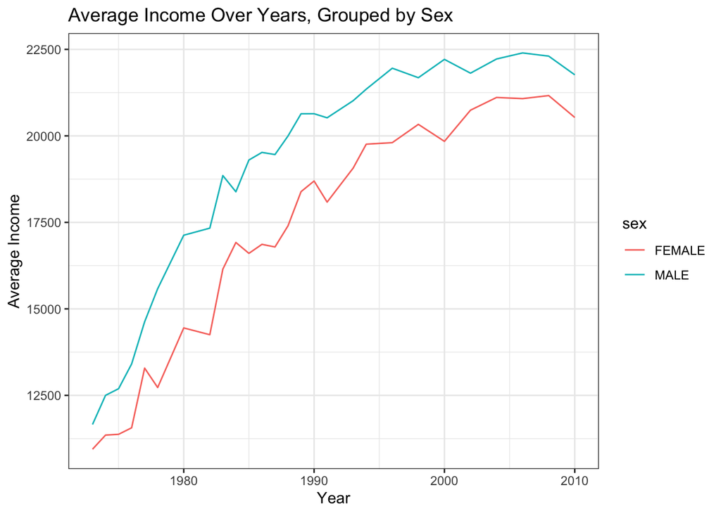

```r
gss %>%
  group_by(sex, year) %>%
  summarize(
    AvgIncome = mean(income1, na.rm = T)
  ) %>%
  ggplot(aes(x = year, y = AvgIncome, color = sex)) +
    geom_line() +
    xlab("Year") +
    ylab("Average Income") +
    ggtitle("Average Income Over Years, Grouped by Sex") +
    theme_bw()
```

*Example*: Get the average of all respondents each year and visualize it

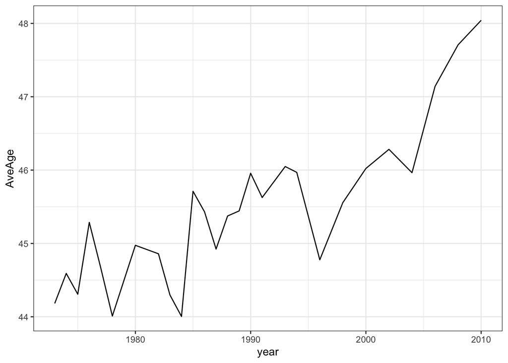

```r
gss %>%
  group_by(year) %>%
  summarize(AveAge = mean(age, na.rm = TRUE)) %>%
  ggplot(aes(x = year, y = AveAge)) +
    geom_line() +
    theme_bw()
```

# `dplyr` Review

## `gss` Data Set

*Exercise 1*: For the `gss` data, get the percent of married respondents by year, Get a plot to visualize the marital status by year.

$\boxed{\text{Method 1}}$

```r
gss %>%
  group_by(year) %>%
  summarize(prec = sum(marital == "MARRIED", na.rm = TRUE) / sum(!is.na(marital))) %>%
  head()
```

```
## # A tibble: 6 × 2
##    year  prec
##   <int> <dbl>
## 1  1973 0.715
## 2  1974 0.718
## 3  1975 0.672
## 4  1976 0.650
## 5  1977 0.637
## 6  1978 0.627
```

$\boxed{\text{Method 2}}$

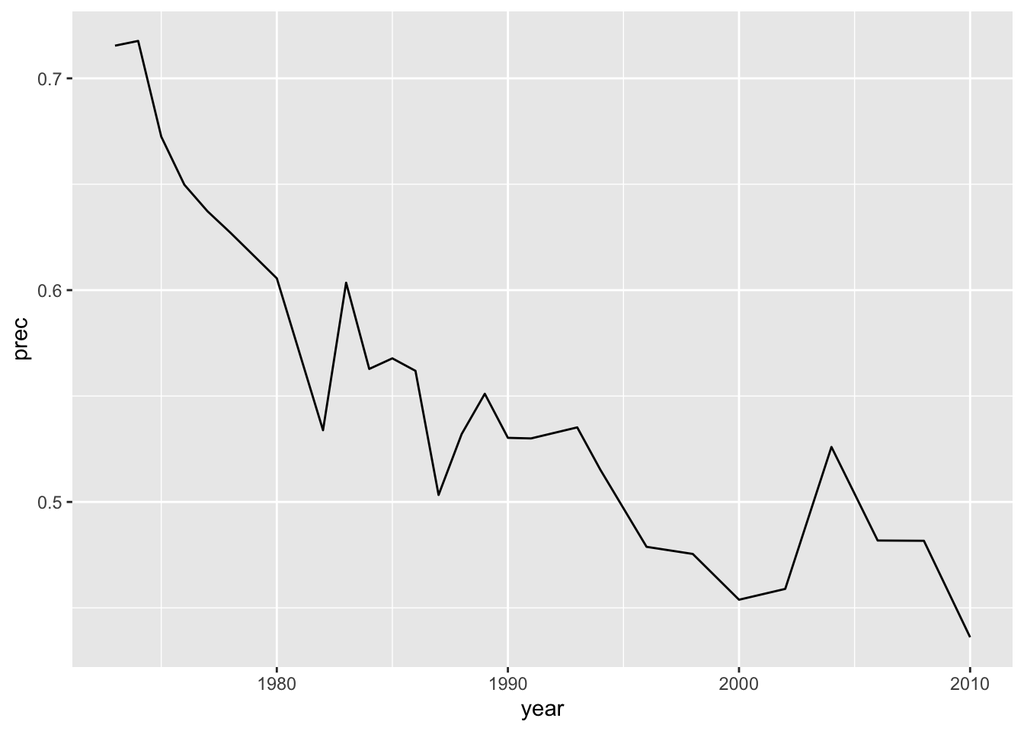

```r
gss %>%
  group_by(year) %>%
  summarize(prec = prop.table(table(marital))[2]) %>%
  ggplot(aes(x = year, y = prec)) +
    geom_line()
```

*Exercise 2*: For the `gss` data, get a data about the percent of married respondents and average age of respondents by year, then provide a plot to visualize the relation between age and marital status by year.

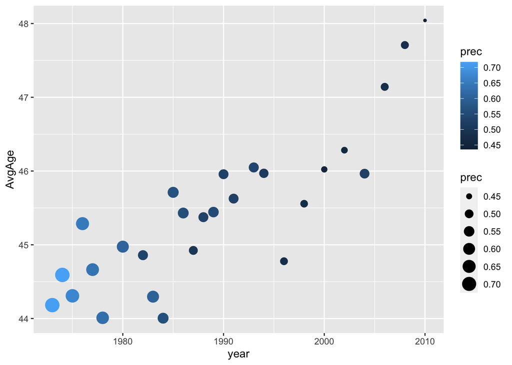

```r
gss %>%
  group_by(year) %>%
 summarize(prec = prop.table(table(marital))[2],
           AvgAge = mean(age, na.rm = TRUE)) %>%
  ggplot(aes(x = year, y = AvgAge, size = prec, color = prec)) +
    geom_point()
```

*Exercise 3*: For the `gss` data, find the percent of respondents with $25,000 or more by party affiliation and year.

```r
gss %>%
  group_by(partyid, year) %>%
  summarize(prec = sum(income == "$25000 OR MORE", na.rm = TRUE) / sum(!is.na(income)) * 100) %>%
  head()
```

```
## # A tibble: 6 × 3
## # Groups:   partyid [1]
##   partyid       year  prec
##   <chr>        <int> <dbl>
## 1 IND NEAR DEM  1973 10.3
## 2 IND NEAR DEM  1974  8.82
## 3 IND NEAR DEM  1975  8.29
## 4 IND NEAR DEM  1976 10.8
## 5 IND NEAR DEM  1977 15.6
## 6 IND NEAR DEM  1978  9.64
```

*Exercise 4*: What is the “richest” region? - does it change over the years?

$\boxed{\text{Method 1}}$

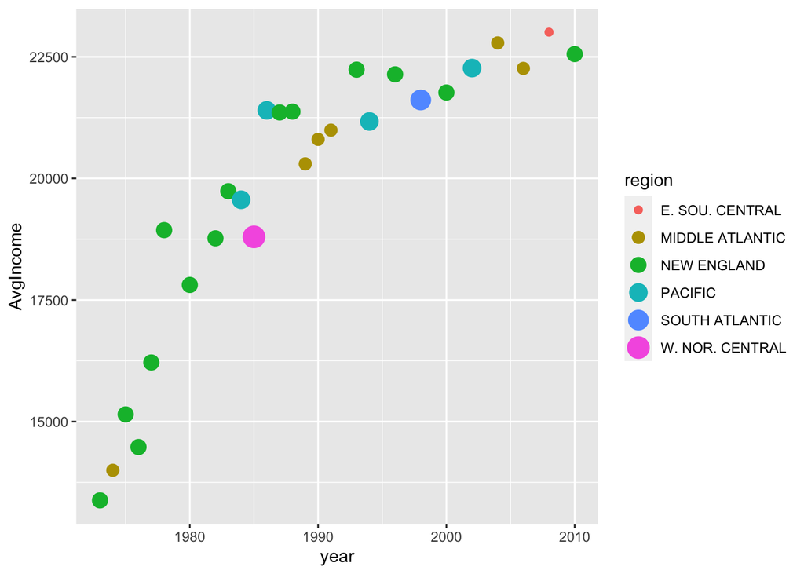

```r
gss %>%
  group_by(year, region) %>%
  summarize(AvgIncome = mean(income1, na.rm = TRUE)) %>%
  filter(AvgIncome == max(AvgIncome)) %>%
  ggplot(aes(x = year, y = AvgIncome, color = region, size = region)) +
    geom_point()
```

$\boxed{\text{Method 2}}$

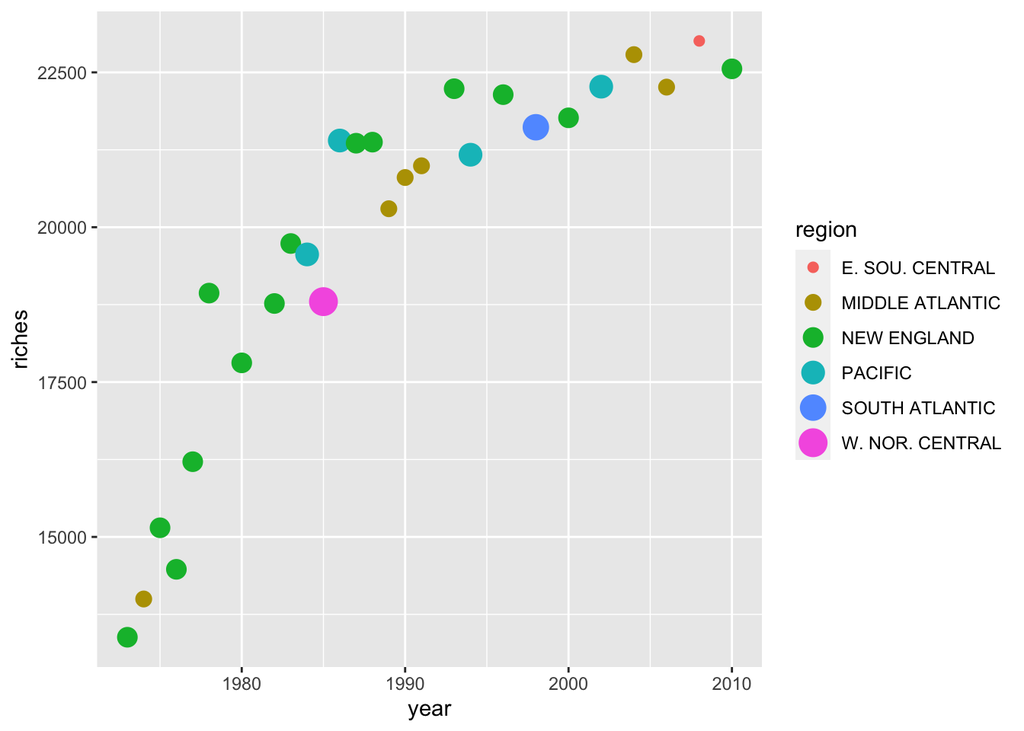

```r
gss %>%
  group_by(year, region) %>%
  summarize(AvgIncome = mean(income1, na.rm = TRUE)) %>%
  group_by(year) %>%
  summarize(riches = max(AvgIncome),
            region = region[which.max(AvgIncome)]) %>%
  ggplot(aes(x = year, y = riches, color = region, size = region)) +
    geom_point()
```

*Extension*: Which region has the lowest income in the year of 1980?

```r
gss %>%
  group_by(year, region) %>%
  summarize(AvgIncome = mean(income1, na.rm = TRUE)) %>%
  group_by(year) %>%
  summarize(riches = min(AvgIncome),
            region = region[which.min(AvgIncome)]) %>%
  filter(year == 1980)
```

```
## # A tibble: 1 × 3
##    year riches region
##   <int>  <dbl> <chr>
## 1  1980  14300 SOUTH ATLANTIC
```

## `babynames` Data Set

```r
str(babynames)
```

```
## tibble [1,924,665 × 5] (S3: tbl_df/tbl/data.frame)
##  $ year: num [1:1924665] 1880 1880 1880 1880 1880 1880 1880 1880 1880 1880 ...
##  $ sex : chr [1:1924665] "F" "F" "F" "F" ...
##  $ name: chr [1:1924665] "Mary" "Anna" "Emma" "Elizabeth" ...
##  $ n   : int [1:1924665] 7065 2604 2003 1939 1746 1578 1472 1414 1320 1288 ...
##  $ prop: num [1:1924665] 0.0724 0.0267 0.0205 0.0199 0.0179 ...
```

```r
summary(babynames)
```

```
##       year          sex                name                 n
##  Min.   :1880   Length:1924665     Length:1924665     Min.   :    5.0
##  1st Qu.:1951   Class :character   Class :character   1st Qu.:    7.0
##  Median :1985   Mode  :character   Mode  :character   Median :   12.0
##  Mean   :1975                                         Mean   :  180.9
##  3rd Qu.:2003                                         3rd Qu.:   32.0
##  Max.   :2017                                         Max.   :99686.0
##       prop
##  Min.   :2.260e-06
##  1st Qu.:3.870e-06
##  Median :7.300e-06
##  Mean   :1.363e-04
##  3rd Qu.:2.288e-05
##  Max.   :8.155e-02
```

*Exercise 5* Create a new variable to see the rank of names from the most popular to the least popular.

```r
babynames %>%
  mutate(rank = min_rank(n)) %>%
  arrange(desc(rank)) %>%
  head()
```

```
## # A tibble: 6 × 6
##    year sex   name        n   prop    rank
##   <dbl> <chr> <chr>   <int>  <dbl>   <int>
## 1  1947 F     Linda   99686 0.0548 1924665
## 2  1948 F     Linda   96209 0.0552 1924664
## 3  1947 M     James   94756 0.0510 1924663
## 4  1957 M     Michael 92695 0.0424 1924662
## 5  1947 M     Robert  91642 0.0493 1924661
## 6  1949 F     Linda   91016 0.0518 1924660
```

Note: `min_rank()` ranks the variable from the minimum to the maximum (i.e., the one with the lowest value is ranked number 1. )

*Extension* Find the most popular name in 2017.

```r
babynames %>%
  mutate(rank = min_rank(n)) %>%
  arrange(desc(rank)) %>%
  filter(year == 2017)
```

```
## # A tibble: 32,469 × 6
##     year sex   name         n    prop    rank
##    <dbl> <chr> <chr>    <int>   <dbl>   <int>
##  1  2017 F     Emma     19738 0.0105  1922391
##  2  2017 M     Liam     18728 0.00954 1922200
##  3  2017 F     Olivia   18632 0.00994 1922186
##  4  2017 M     Noah     18326 0.00933 1922119
##  5  2017 F     Ava      15902 0.00848 1921470
##  6  2017 F     Isabella 15100 0.00805 1921205
##  7  2017 M     William  14904 0.00759 1921144
##  8  2017 F     Sophia   14831 0.00791 1921116
##  9  2017 M     James    14232 0.00725 1920898
## 10  2017 M     Logan    13974 0.00712 1920808
## # … with 32,459 more rows
```

*Exercise 6* For `babynames` data set, visualize the trend of born children population over years.

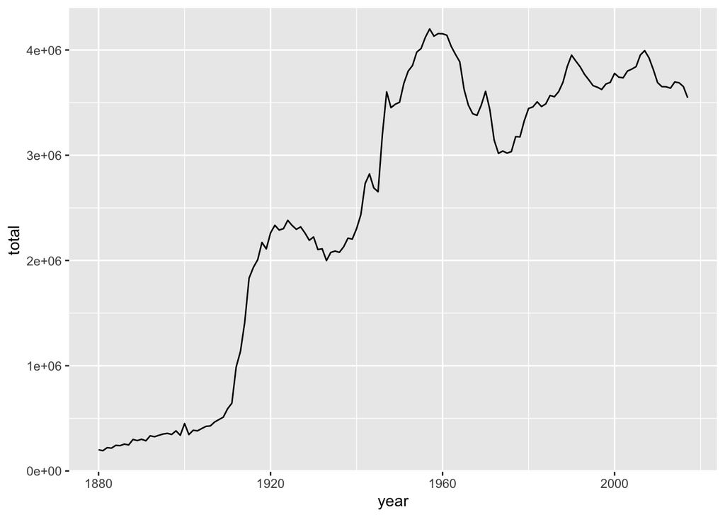

```r
babynames %>%
  group_by(year) %>%
  summarize(total = sum(n)) %>%
  ggplot(aes(x = year, y = total)) +
    geom_line()
```

*Exercise 7* Find the number of unique names in the year 2017.

```r
babynames %>%
  group_by(name) %>%
  filter(year == 2017) %>%
  summarize(total = sum(n)) %>%
  count(name) %>%
  filter(n == 1) %>%
  summarize(total = sum(n))
```

```
## # A tibble: 1 × 1
##   total
##   <int>
## 1 29910
```

Note: `count(variable) = group_by(variable) %>% summarize(n())` (the number of observations in each group). `n()` is the number observations in each group. `count()` is different from `sum(numeric variable)`.

*Exercise 8* Provide an appropriate to visualize the top 5 popular names for both girl and boy.

$\boxed{\text{Method 1}}$

[output not shown]

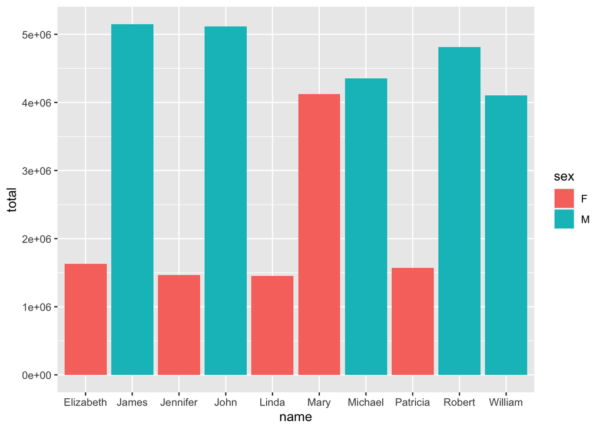

```r
babynames %>%
  group_by(sex, name) %>%
  summarize(total = sum(n)) %>%
  top_n(5) %>%
  ggplot(aes(x = name, y = total)) +
    geom_bar(stat = "identity", aes(fill = sex))
```

Note: `geom_col() = geom_bar(stat = "identity")`

$\boxed{\text{Method 2}}$

[output not shown]

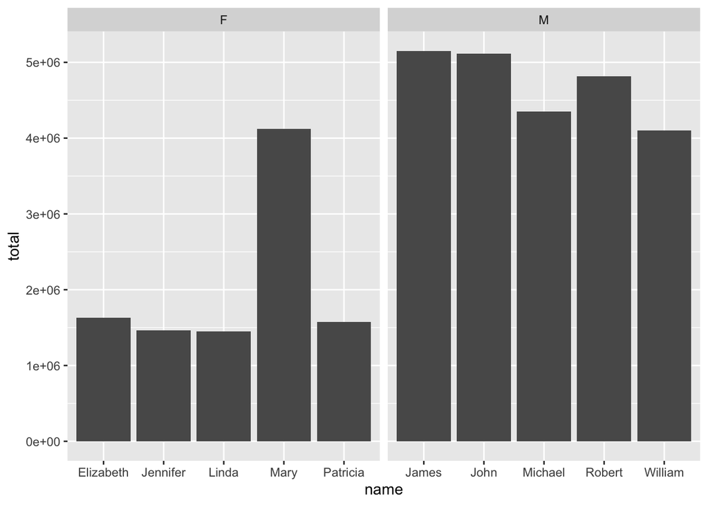

```r
babynames %>%
  group_by(sex, name) %>%
  summarize(total = sum(n)) %>%
  top_n(5) %>%
  ggplot(aes(x = name, y = total)) +
    geom_bar(stat = "identity") +
    facet_grid(.~sex, scale = "free")
```

*Exercise 9* The top 5 most popular names in 2000, see their trend over years Finding the 5 most popular names in 2000:

```r
namesIn2000 <- babynames %>%
  filter(year == 2000) %>%
  group_by(name) %>%
  summarize(total = sum(n)) %>%
  top_n(5) %>%
  select(name)
```

Converting `namesIn2000` to vector.

```r
as.vector(namesIn2000)
```

```
## $name
## [1] "Emily"   "Jacob"   "Joshua"  "Matthew" "Michael"
```

```r
class(as.vector(namesIn2000))
```

```
## [1] "list"
```

```r
class(as.vector(namesIn2000)[[1]])
```

```
## [1] "character"
```

Complete the exercise

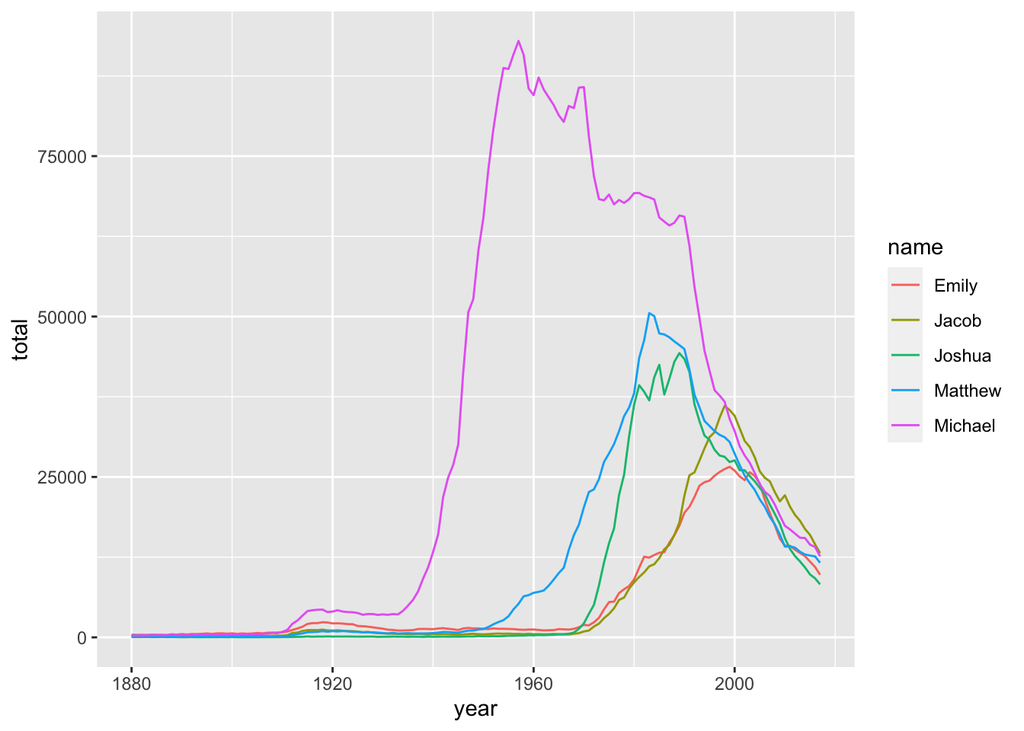

```r
babynames %>%
  filter(name %in% namesIn2000[[1]]) %>%
  group_by(year, name) %>%
  summarize(total = sum(n)) %>%
  ggplot(aes(x = year, y = total, color = name)) +
    geom_line()
```

# Join

## Pakcage: nycflights13

We will use the `nycflights13` package to learn about relational data. `nycflights13` contains four data tables that are related to the main `flights` table:

```r
library(nycflights13)
```

The `flights` data set is the main data set.

```r
head(flights)
```

```
## # A tibble: 6 × 19
##    year month   day dep_time sched_dep…¹ dep_d…² arr_t…³ sched…⁴ arr_d…⁵ carrier
##   <int> <int> <int>    <int>       <int>   <dbl>   <int>   <int>   <dbl> <chr>
## 1  2013     1     1      517         515       2     830     819      11 UA
## 2  2013     1     1      533         529       4     850     830      20 UA
## 3  2013     1     1      542         540       2     923     850      33 AA
## 4  2013     1     1      544         545      -1    1004    1022     -18 B6
## 5  2013     1     1      554         600      -6     812     837     -25 DL
## 6  2013     1     1      554         558      -4     740     728      12 UA
## # … with 9 more variables: flight <int>, tailnum <chr>, origin <chr>,
## #   dest <chr>, air_time <dbl>, distance <dbl>, hour <dbl>, minute <dbl>,
## #   time_hour <dttm>, and abbreviated variable names ¹sched_dep_time,
## #   ²dep_delay, ³arr_time, ⁴sched_arr_time, ⁵arr_delay
```

Relational data sets:

- `plane`connects to the main data set via a single variable `tailnum`

```r
head(planes)
```

```
## # A tibble: 6 × 9
##   tailnum  year type                    manuf…¹ model engines seats speed engine
##   <chr>   <int> <chr>                   <chr>   <chr>   <int> <int> <int> <chr>
## 1 N10156   2004 Fixed wing multi engine EMBRAER EMB-…       2    55    NA Turbo…
## 2 N102UW   1998 Fixed wing multi engine AIRBUS… A320…       2   182    NA Turbo…
## 3 N103US   1999 Fixed wing multi engine AIRBUS… A320…       2   182    NA Turbo…
## 4 N104UW   1999 Fixed wing multi engine AIRBUS… A320…       2   182    NA Turbo…
## 5 N10575   2002 Fixed wing multi engine EMBRAER EMB-…       2    55    NA Turbo…
## 6 N105UW   1999 Fixed wing multi engine AIRBUS… A320…       2   182    NA Turbo…
## # … with abbreviated variable name ¹manufacturer
```

- `airports` connects to the main data setvia two variables `dest` = `faa`

```r
head(airports)
```

```
## # A tibble: 6 × 8
##   faa   name                             lat   lon   alt    tz dst   tzone
##   <chr> <chr>                          <dbl> <dbl> <dbl> <dbl> <chr> <chr>
## 1 04G   Lansdowne Airport               41.1 -80.6  1044    -5 A     America/Ne…
## 2 06A   Moton Field Municipal Airport   32.5 -85.7   264    -6 A     America/Ch…
## 3 06C   Schaumburg Regional             42.0 -88.1   801    -6 A     America/Ch…
## 4 06N   Randall Airport                 41.4 -74.4   523    -5 A     America/Ne…
## 5 09J   Jekyll Island Airport           31.1 -81.4    11    -5 A     America/Ne…
## 6 0A9   Elizabethton Municipal Airport  36.4 -82.2  1593    -5 A     America/Ne…
```

- `airlines` connects to the main data set through the `carrier` variable

```r
head(airlines)
```

```
## # A tibble: 6 × 2
##   carrier name
##   <chr>   <chr>
## 1 9E      Endeavor Air Inc.
## 2 AA      American Airlines Inc.
## 3 AS      Alaska Airlines Inc.
## 4 B6      JetBlue Airways
## 5 DL      Delta Air Lines Inc.
## 6 EV      ExpressJet Airlines Inc.
```

- `weater` connects to the main data set via `origin`, `year`, `month`, `day`, and `hour`

```r
head(weather)
```

```
## # A tibble: 6 × 15
##   origin  year month   day  hour  temp  dewp humid wind_dir wind_speed wind_gust
##   <chr>  <int> <int> <int> <int> <dbl> <dbl> <dbl>    <dbl>      <dbl>     <dbl>
## 1 EWR     2013     1     1     1  39.0  26.1  59.4      270      10.4         NA
## 2 EWR     2013     1     1     2  39.0  27.0  61.6      250       8.06        NA
## 3 EWR     2013     1     1     3  39.0  28.0  64.4      240      11.5         NA
## 4 EWR     2013     1     1     4  39.9  28.0  62.2      250      12.7         NA
## 5 EWR     2013     1     1     5  39.0  28.0  64.4      260      12.7         NA
## 6 EWR     2013     1     1     6  37.9  28.0  67.2      240      11.5         NA
## # … with 4 more variables: precip <dbl>, pressure <dbl>, visib <dbl>,
## #   time_hour <dttm>
```

## Definitions

The variables used to connect each pair of tables are called *keys*. A key is a variable (or set of variables) that uniquely identifies an observation.

A *primary key* variable uniquely identify each observation

*Example* syaing each `tailnum` only has one observation (`tailnum` is the primary key variable in planes) is equivalent to say that `tailnum` is the foreign key in flights (uniquely identifies an observation in another table)

```r
planes %>%
  group_by(tailnum) %>%
  summarize(amount = n()) %>%
  filter(amount != 1)
```

```
## # A tibble: 0 × 2
## # … with 2 variables: tailnum <chr>, amount <int>
```

- `n()` is to calculate the number of occurrences of each observation
- `count()` is to calculate the number of occurrences of each observation, the same as the below `group_by()+summarize(n())`

```r
planes %>%
  count(tailnum) %>%
  filter(n != 1)
```

```
## # A tibble: 0 × 2
## # … with 2 variables: tailnum <chr>, n <int>
```